# Assignment 2

Ryan Johnson

9/17/2020

## Description

This assignment deals with visualizing various map projections and utilizing maps to demonstrate variations in data.

## Map projections

In this section, I create a map of the contiguous 48 US states, and project it using three different projections - the Albers equal area projection, the Texas State Plane - Central Zone 3 (a variant of the Lambert Conformal Conic projection), and the Gall-Peters projection. These coordinate systems are stored in the following vectors:

```r
USA_AEA <- "+proj=aea +lat_1=29.5 +lat_2=45.5 +lat_0=23 +lon_0=-96 +x_0=0 +y_0=0 +ellps=clrk66 +units=m +no_defs"
TxStateCent <- "ESRI:102739"
GallPeters <- "+proj=cea +lon_0=0 +lat_ts=45 +x_0=0 +y_0=0 +ellps=WGS84 +units=m +no_defs"
```

### Map of continental United States - Gall-Peters projection

First, I create a new data frame entitled **USA_States** which contains the r/naturalearth simple features information for the contiguous 48 US states.

Then, I plot this using the Gall-Peters projection.

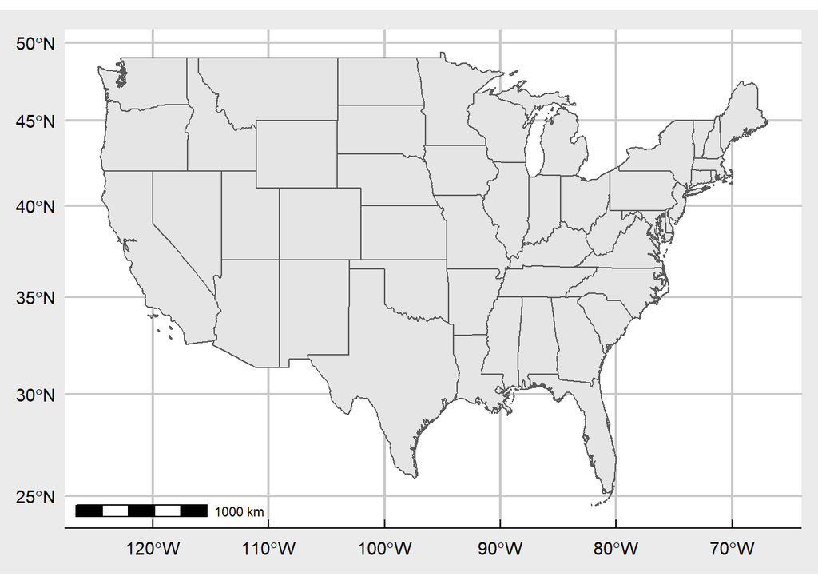

```r
USA_states <- ne_states(country = "United States of America",
                       returnclass = "sf") %>%
  filter(name != "Alaska",
         name != "Hawaii")

USA_map <- ggplot(USA_states) +
  geom_sf() +
  coord_sf(crs = GallPeters) +
  theme_economist_white()

USA_map +
  annotation_scale()
```

### Map of continental United States - Albers equal area projection

The same map as above, plotted using the Albers equal area projection.

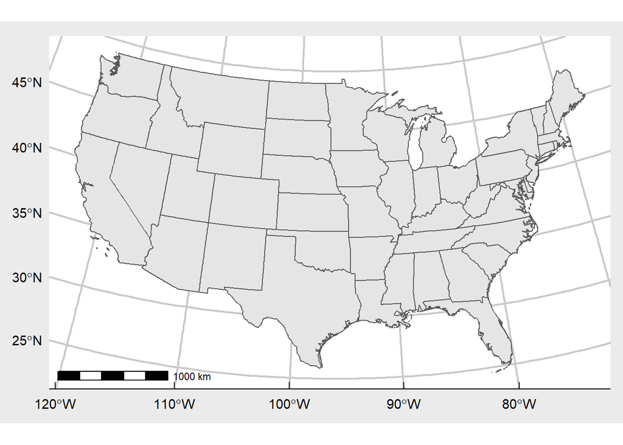

```r
ggplot(USA_states) +
  geom_sf() +
  coord_sf(crs = USA_AEA) +
  theme_economist_white() +
  annotation_scale()
```

### Map of continental United States - Texas State Plane (Lambert conformal conic) projection

Once more, the same as above, plotted using the Texas State Plane Zone 3 Lambert projection.

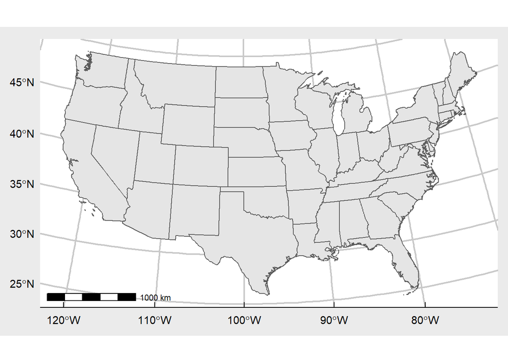

```r
ggplot(USA_states) +
  geom_sf() +
  coord_sf(crs = TxStateCent) +
  theme_economist_white() +
  annotation_scale()
```

### Transforming coordinate system - AEA

Finally, I transform **USA_states** into an AEA projected coordinate system. This projected data is stored in **USA_transform_AEA** for use in the next section.

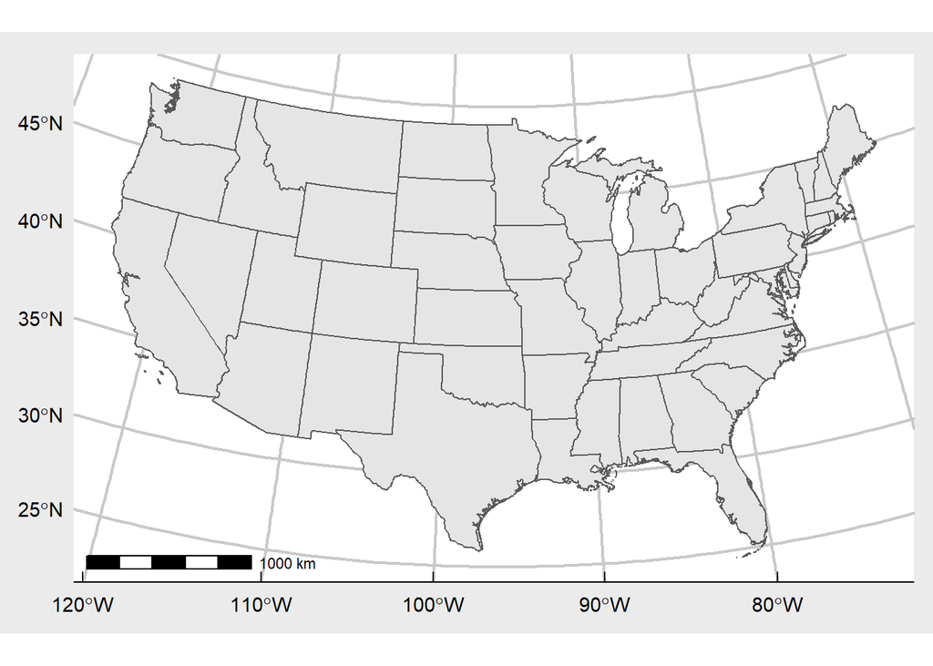

```r
USA_transform_AEA <- USA_states %>%
  st_transform(crs = USA_AEA)

ggplot(USA_transform_AEA) +
  geom_sf() +
  theme_economist_white() +
  annotation_scale()
```

## Visualization of variable(s)

In this section, I create a chloropleth map, cartograms, and a proportional symbol map to visualize the spatial distribution and variation of population density in the contiguous 48 states.

To accomplish this, I load a dataset from the US Census Bureau containing the name of each state and its population density (measured in people per square mile). I name this data frame **state_data**.

```r
state_data <- read.csv("USA_pop_density.csv")
```

Next, I join this density data to my **USA_transform_AEA** data frame, then filter out the District of Columbia (with a density of over 11,000 people/sq. mi., this was an extreme outlier, and its small size made it invisible on the maps), resulting in the new frame **USA_density**.

```r
density_states <- USA_transform_AEA %>%
  left_join(state_data, by = c("name" = "State")) %>%
  select(name, Density)

USA_density <- density_states %>%
    filter(name != "District of Columbia")
```

### Chloropleth map

Below, I plot my **USA_density** data frame with a fill correlated to the density value. I use a logarithmic scale for the density values, as the data included a few observations over 1,000 people/sq. mi., and many observations in the 5 to 500 people/sq. mi. range.

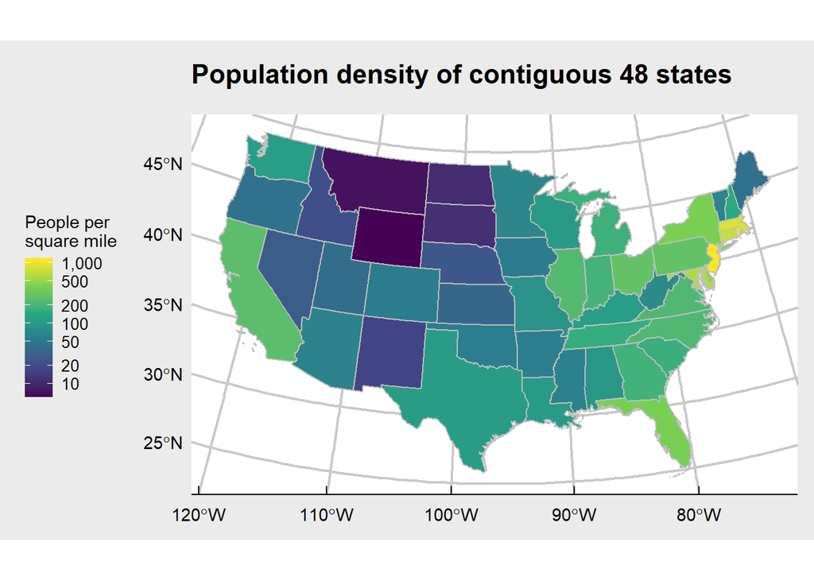

```r
ggplot(USA_density, aes(fill = Density)) +
  geom_sf(color = "grey75") +
  scale_fill_viridis_c(name = "People per\nsquare mile",
                       trans = "log",
                       breaks = c(0, 10, 20, 50, 100, 200, 500, 1000),
                       labels = formatC(c(0, 10, 20, 50, 100, 200, 500, 1000),
                                        big.mark = ",", format = "f", digits = 0)) +
  theme_economist_white() +
  theme(legend.background = element_blank(),
        legend.position = "left",
        legend.text = element_text(size = 10)) +
  ggtitle("Population density of contiguous 48 states\n")
```

### Cartograms

The following three variants of cartograms represent the same density data as above with fill, while manipulating the size of each state in relation to its 2019 estimated total population.

Because my **USA_Density** dataset included only *Density* and *name* variables, I had to add a third, *pop2019*, by performing another join() function. The data I added was the US Census Bureau’s 2019 state population estimate.

```r
USA_pop <- read.csv("USA_pop_2019.csv")
```

```r
USA_density_pop <- USA_density %>%
  left_join(USA_pop, by = "name") %>%
  filter(name != "District of Columbia") %>%
  select(name, Density, pop2019)
```

#### **Continuous cartogram**

This cartogram distorts the shape and area of each state according to population size.

```r
density_cart_cont <- USA_density_pop %>%
  cartogram_cont("pop2019")
```

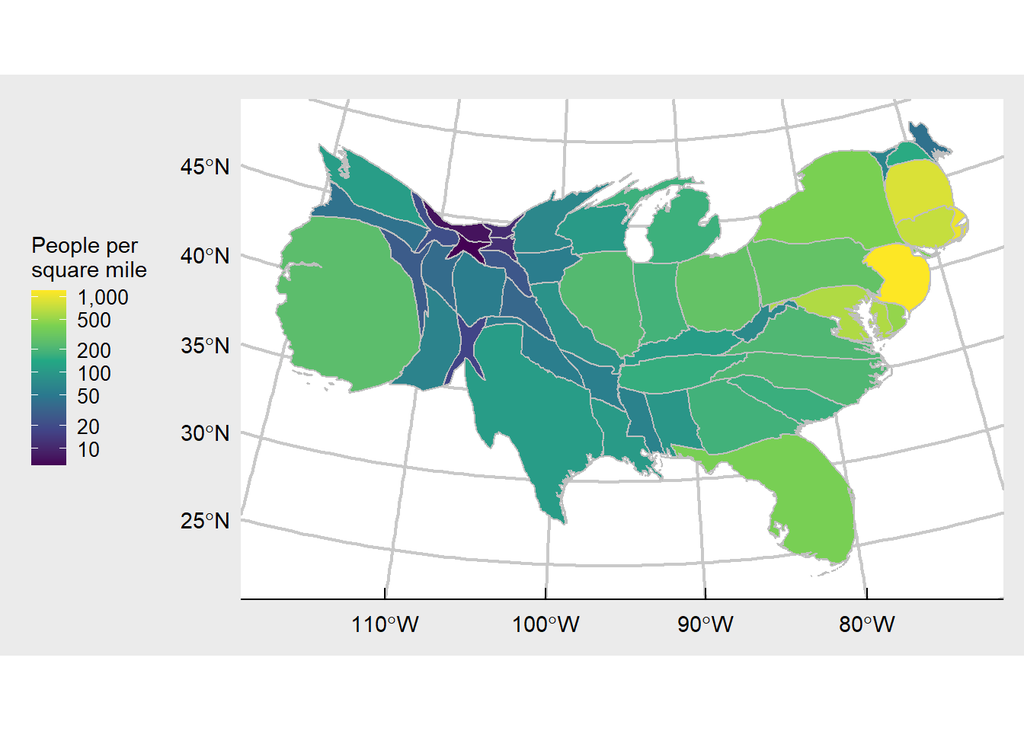

```r
ggplot(density_cart_cont, aes(fill = Density)) +
  geom_sf(color = "grey75") +
  scale_fill_viridis_c(name = "People per\nsquare mile",
                       trans = "log",
                       breaks = c(0, 10, 20, 50, 100, 200, 500, 1000),
                       labels = formatC(c(0, 10, 20, 50, 100, 200, 500, 1000),
                                        big.mark = ",", format = "f", digits = 0)) +
  theme_economist_white() +
  theme(legend.background = element_blank(),
        legend.position = "left",
        legend.text = element_text(size = 10))
```

#### **Non-continuous cartogram**

This cartogram distorts the area of each state, but not the shape.

```r
density_cart_ncont <- USA_density_pop %>%
  cartogram_ncont("pop2019")
```

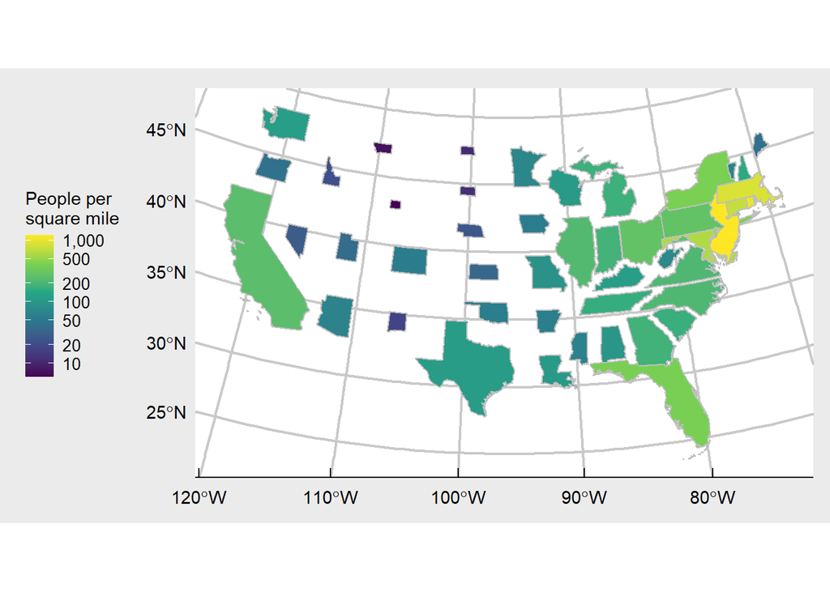

```r
ggplot(density_cart_ncont, aes(fill = Density)) +
  geom_sf(color = "grey75") +
  scale_fill_viridis_c(name = "People per\nsquare mile",
                       trans = "log",
                       breaks = c(0, 10, 20, 50, 100, 200, 500, 1000),
                       labels = formatC(c(0, 10, 20, 50, 100, 200, 500, 1000),
                                        big.mark = ",", format = "f", digits = 0)) +
  theme_economist_white() +
  theme(legend.background = element_blank(),
        legend.position = "left",
        legend.text = element_text(size = 10))
```

#### **Dorling cartogram**

In the Dorling cartogram, the state outlines are replaced entirely by circles scaled to population size.

```r
density_cart_dorling <- USA_density_pop %>%
  cartogram_dorling("pop2019")
```

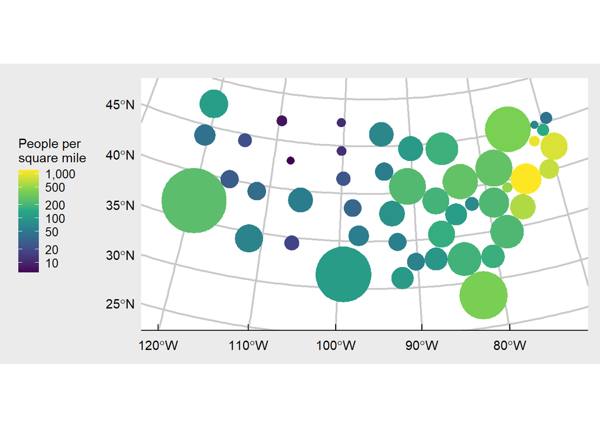

```r
ggplot(density_cart_dorling, aes(fill = Density)) +
  geom_sf(color = NA) +
  scale_fill_viridis_c(name = "People per\nsquare mile",
                       trans = "log",
                       breaks = c(0, 10, 20, 50, 100, 200, 500, 1000),
                       labels = formatC(c(0, 10, 20, 50, 100, 200, 500, 1000),
                                        big.mark = ",", format = "f", digits = 0)) +
  theme_economist_white() +
  theme(legend.background = element_blank(),
        legend.position = "left",
        legend.text = element_text(size = 10))
```

### Proportional symbol map

Finally, the proportional symbol map below places a filled circle scaled to the density value over each state. For this map, I reverted to a linear scale for density, as the logarithmic scale resulted in too many large circles, which made the map difficult to interpret.

```r
density_centroids <- USA_density_pop %>%
  st_centroid()
```

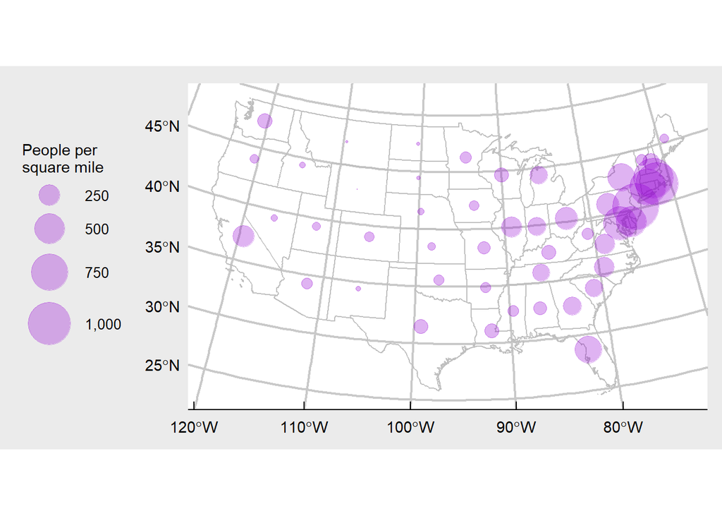

```r
ggplot(USA_transform_AEA) +
  geom_sf(fill = NA, color = "grey75") +
  geom_sf(data = density_centroids,
          aes(size = Density),
          alpha = 0.3, color = "darkviolet") +
  scale_size_continuous(name = "People per\nsquare mile",
                        breaks = seq(0, 1000, by = 250),
                        labels = formatC(seq(0, 1000, by = 250),
                                         big.mark = ",", format = "f", digits = 0),
                        range = c(0, 15)) +
  theme_economist_white() +
  theme(legend.background = element_blank(),
        legend.position = "left",
        legend.text = element_text(size = 10))
```